# Trees

- Traversals Method 1
- Traversals Method 2
- Traversals Method 3

## Traverse Method 1

Draw a line (base) at bottom, draw line on left side of each node, and connect to base line

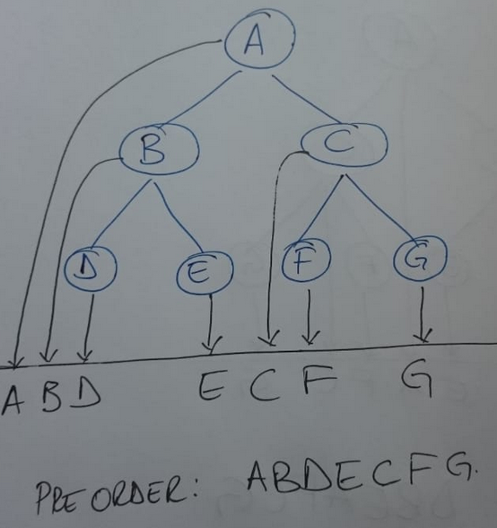

Draw a line (base) at bottom, draw in bottom middle of each node, and connect to base line

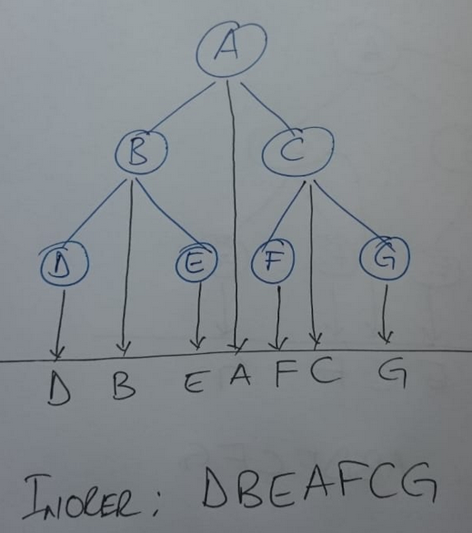

Draw a line (base) at bottom, draw line on right side of each node, and connect to base line

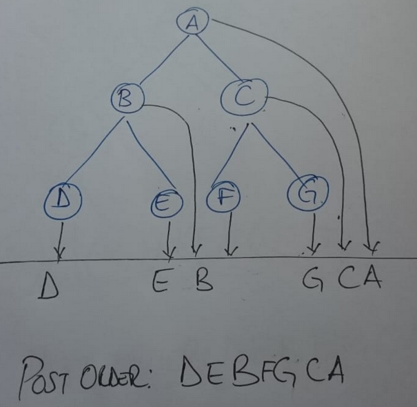

## Traverse Method 2

Draw a line on left side of each node, then starting as root follow contour of each node

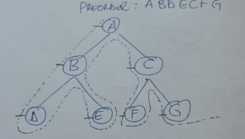

Draw a line on middle bottom of each node, then starting as root follow contour of each node

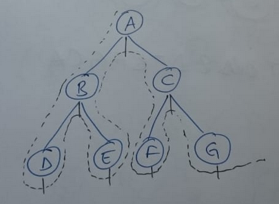

Draw a line on right side of each node, then starting as root follow contour of each node

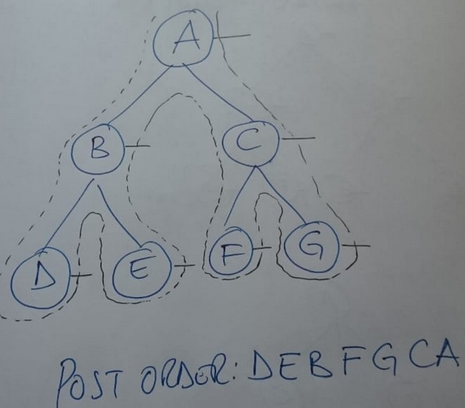

## Traverse Method 3

Use your finger pointing to right toward each node, then starting as root follow contour of each node.

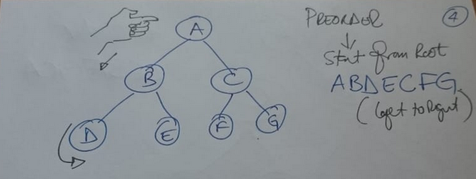

Use your finger pointing upwards toward each node, then starting as root follow contour of each node.

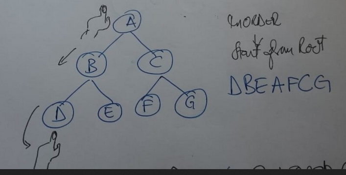

Use your finger pointing to left towards each node, then starting as root follow contour of each node.

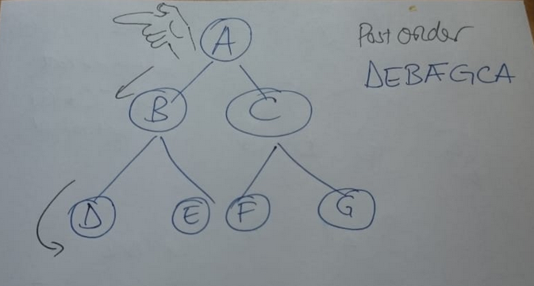